# Histograms: More Than Meets The Plot

Edie Espejo

7 May 2019

The way I’ve taught histograms in the past is simple. You take a numeric variable, then you use `ggplot2`, and slap it onto your x aesthetic. Then, run your code chunk. Once you’ve done so, choose appropriate binwidths that show the relationship of the data frequencies. Then, you’d have your acceptable histogram. Instead of calling it a day right there, let’s start thinking about how we can define histograms in math notation.

# 1 The Anatomy of a Histogram

Each of the rectangles on a histogram is a **bin**. Bins are intervals defined as

$$B_1 = [0, \frac{1}{m}), B_2 = [\frac{1}{m}, \frac{2}{m}), ..., B_m = [\frac{m-1}{m}, \frac{m}{m}).$$

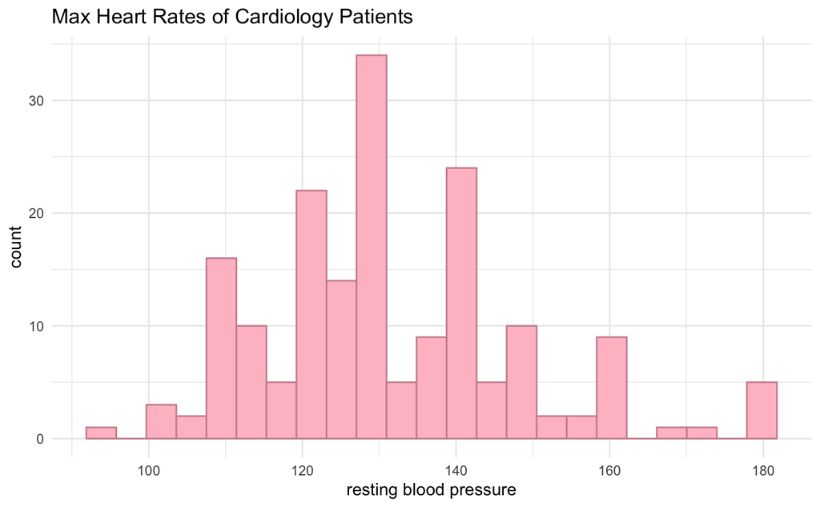

```r
# * DECIDING MY BINWIDTH BASED ON VISUALS
our_range <- range(heart_data$resting_blood_pressure)[2] - range(heart_data$resting_blood_pressure)[1]
# * PLOTTING
ggplot(heart_data, aes(x=resting_blood_pressure)) +
  geom_histogram(binwidth=our_range/22, col="pink3", fill="pink") +
  xlab("resting blood pressure") +
  ggtitle("Max Heart Rates of Cardiology Patients") +
  theme_minimal()
```

When I teach, this is where I’d call it the “end of the day” for the histogram. We got to see an overall density pattern, and that’s all it’d be used for: visual purposes. In this blog, we’ll see how histograms are estimators for the true probability density of a random variable.

In the above histogram, $h \approx 3.909$. This doesn’t seem like it quite fits the bill of $h=\frac{1}{m}$, but this is because our $X_1, ..., X_n$ are not $iid \sim \, f \in [0,1]$. Let’s see what happens if we fix our data to be on the interval $[0,1]$.

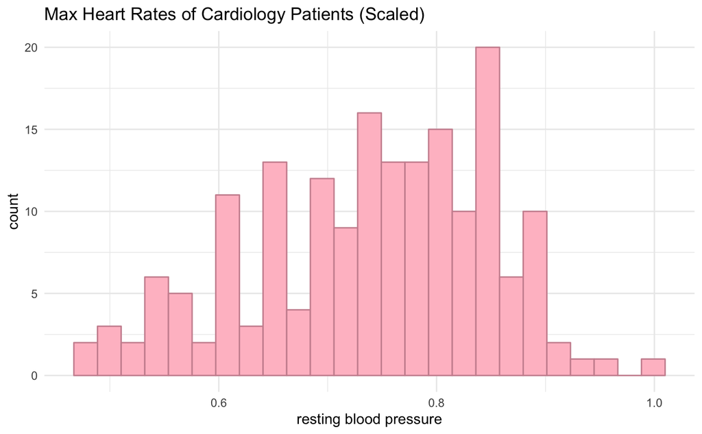

```r
# * RESCALING WITH MUTATE
heart_data <- heart_data %>% mutate(heart_rescale=max_heart_rate_achieved/max(max_heart_rate_achieved))
# * DECIDING MY NEW BINWIDTH BASED ON VISUALS
our_range_2 <- our_range / max(heart_data$resting_blood_pressure)
# * PLOTTING
ggplot(heart_data, aes(x=heart_rescale)) +
  geom_histogram(binwidth=our_range_2/22, col="pink3", fill="pink") +
  xlab("resting blood pressure") +
  ggtitle("Max Heart Rates of Cardiology Patients (Scaled)") +
  theme_minimal()
```

Having done the transformation, we are intrigued to see our histogram shape shift. Now, we can start diving into histogram estimators.

# 2 The Histogram Estimator

Let $c_j$ be the number of observations in $B_j$. We’ll let the probability of being in each bin be $\hat{p}_j=c_j/n$. Finally, also let $p_j=\int_{B_j} f(u) du$. Our **histogram estimator** is defined as follows

$$\hat{f}_n(x)=\sum_{i=1}^{n} \frac{\hat{p}_j}{h} \textbf{1}_{\{x \in B_j\}}.$$

The histogram estimator $\hat{f}_n(x)$ has expectation $E(\hat{f}_n(x)) \approx f(x)$ where $f(x)$ is the true probability density.

# 3 Expectation and Variance of the Histogram Estimator

The expectation of the histogram estimator is

$$E(\hat{f}_n(x)) = \frac{p_j}{h}$$
and

$$\text{Var}(\hat{f}_n(x)) = \frac{p_j(1-p_j)}{nh^2}$$

# 4 Choosing Binwidth Based on the Bias-Variance Tradeoff

Recall that

$$\text{Risk}(\theta)=\text{Bias}^2(\theta) + \text{Var}(\theta)$$

for some arbitrary estimator $\theta$. Making use the expectation and variance of the histogram estimator, the bias-variance tradeoff, and the fact that for any $u \in B_j$, $f(u) \approx f(x)+(u-x)f'(x)$, we can calculate an optimal binwidth.

## 4.1 By Theorem

The following theorem shows that you can choose an optimal binwidth for your histogram estimator to minimize risk (mean integrated square error - MISE). The theorem shows that there does indeed exist an optimal binwidth, but it is based on the true distribution of $f(u)$ which we don’t have in practice. *This is Theorem 20.4 in Wasserman.*

Given that $\int [f'(u)]^2 du < \infty$, we have that

$$\text{Risk}(\hat{f}_n, f) \approx \frac{h^2}{12} \int [f'(u)]^2 du + \frac{1}{nh}.$$

The value that of $h$ (the binwidth size) that minimizes the above risk is

$$h^*= \frac{1}{n^{1/3}} \bigg( \frac{6}{\int [f'(u)]^2 du} \bigg)^{1/3}.$$

When that binwidth is chosen, $\text{Risk}(\hat{f}_n, f) \approx \frac{C}{n^{2/3}}$ where $C=(3/4)^{2/3}\big( \int [f'(u)]^2 du \big)^{1/3}$. The MISE converges to 0 at a rate $n^{-2/3}$.

## 4.2 By Estimation

In practice, we would be interested in estimating the risk function so that it doesn’t depend on $f(u)$. The **cross-validation estimator of risk** (estimated risk) is

$$\hat{J}(h) = \int [f'_n(x)]^2 dx - \frac{2}{n}\sum_{i=1}^{n} \hat{f}_{(-i)}(X_i).$$
The $(-i)$ stands for the removal of the $i^{th}$ observation. Also,

$$\hat{J}(h) = \frac{2}{(n-1)h} - \frac{(n+1)}{(n-1)} \sum_{j=1}^{m} \hat{p}_j^2.$$

## 4.3 Estimating Risk for Heart Disease Data

Let’s look back at the heart disease data. To estimate risk, I am going to use Wasserman’s `cv.hist.fun` from the All of Statistics website. Source code is available [here](https://www.stat.cmu.edu/~larry/all-of-statistics/=Rprograms/density.examples.r). The code implements the second formula for cross-validated risk estimate: $\hat{J}(h) = \frac{2}{(n-1)h} - \frac{(n+1)}{(n-1)} \sum_{j=1}^{m} \hat{p}_j^2$.

```r
# * USING WASSERMAN'S FUNCTION
source("histograms-1-source.R")
function_output <- cv.hist.fun(heart_data %>% pull(heart_rescale))
risk_estimates <- data.frame(cbind(h=function_output$h, n_bins=function_output$nbins, est_risk=function_output$risk))
risk_estimates %>% pull(est_risk) %>% summary()
```

```
   Min. 1st Qu.  Median    Mean 3rd Qu.    Max.
 -3.040  -2.470  -2.327  -2.333  -2.159  -1.794
```

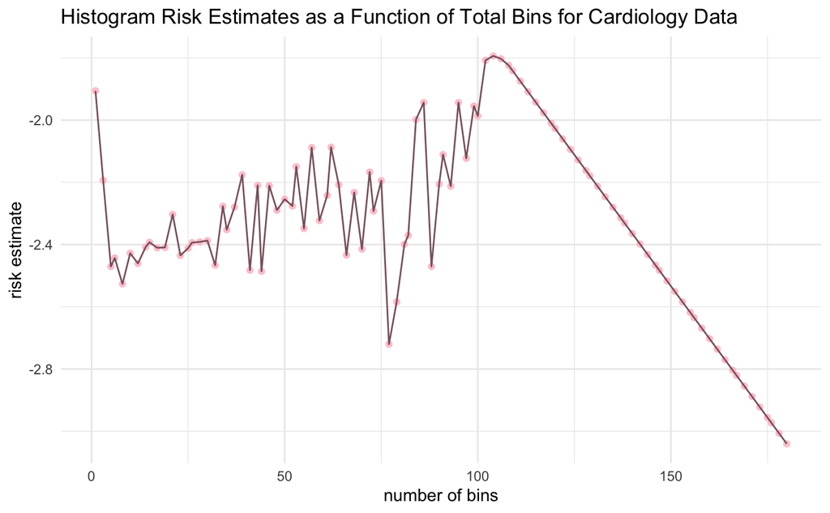

According to this output, having 180 bins minimizes estimated MISE. Since this matches the value of $n$, it may lead you to think each bin is an observation. however, this definitely does not correspond to each observation having a bin. Recall that having 180 bins means

where $m=180$. This does not guarantee that there will only be one value in each of these bins.

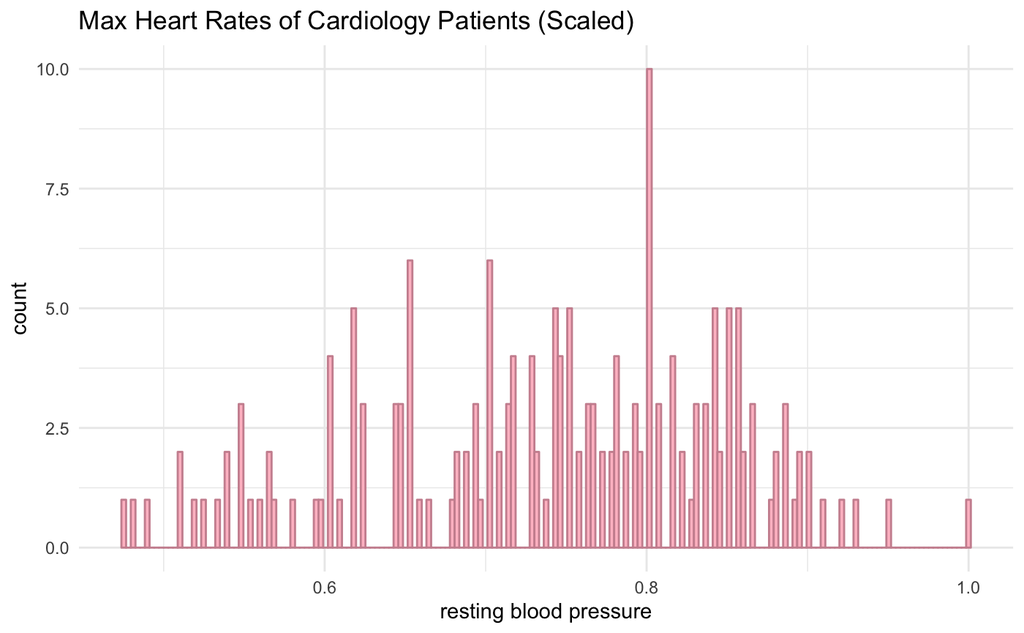

```r
h <- function_output$hbest
# * PLOTTING
ggplot(heart_data, aes(x=heart_rescale)) +
  geom_histogram(binwidth=h, col="pink3", fill="pink") +
  xlab("resting blood pressure") +
  ggtitle("Max Heart Rates of Cardiology Patients (Scaled)") +
  theme_minimal()
```

# 5 Confidence Bands

According to Wasserman’s 20.9 Definition, a pair of functions $l(x)$ (lower) and $u(x)$ (upper) is a $1-\alpha$ confidence band if P($\bar{f}_n(x)$ of being within the two functions) $\geq 1-\alpha$. That is,

$$P\big(l(x) < \bar{f}_n(x) < u(x)\big) \geq 1-\alpha$$

where $\bar{f}_n(x)=E(\hat{f}_n(x)) = \frac{p_j}{h} \, \forall x\in B_j$ and where $p_j=\int_{B_j}f(u)du$.

Using a function from Wasserman, we calculate a 95% confidence band. The lines below stand for the “top” of the histogram. Imagine the diagram to be shaded below those lines. The middle line stands for $\bar{f}_n(x)$.

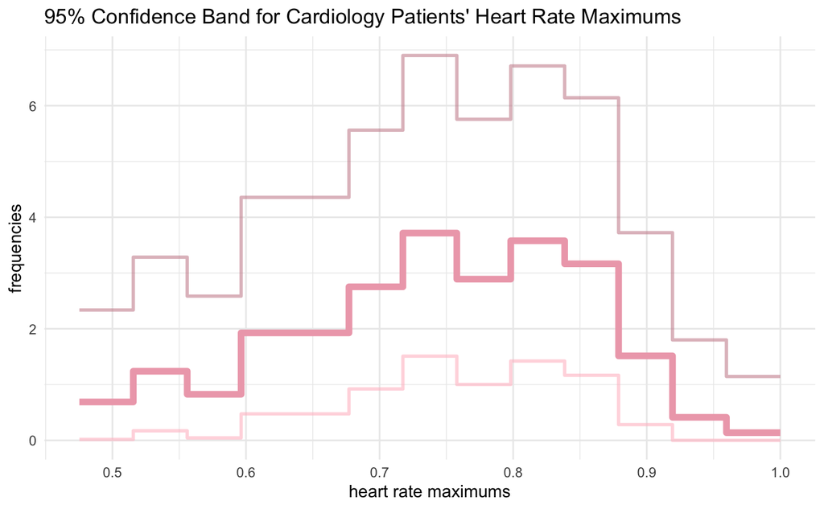

```r
# * USING WASSERMAN'S FUNCTION
source("histograms-1-source.R")
function_output_2 <- ci.fun(heart_data %>% pull(heart_rescale))
envelope_df <- data.frame(cbind(grid=function_output_2$Grid, u=function_output_2$U, l=function_output_2$L, f=function_output_2$F))
# * PLOTTING ENVELOPE
ggplot(envelope_df, aes(x=grid)) +
  geom_line(stat="identity", aes(x=grid, y=u), col="pink3", lwd=1, alpha=0.6) +
  geom_line(stat="identity", aes(x=grid, y=f), col="pink2", lwd=2) +
  geom_line(stat="identity", aes(x=grid, y=l), col="pink", lwd=1, alpha=0.6) +
  theme_minimal() +
  xlab("heart rate maximums") +
  ylab("frequencies") +
  ggtitle("95% Confidence Band for Cardiology Patients' Heart Rate Maximums")
```

At least to me, histograms have a lot more life to them than they used to. If you had to remember one thing from this blog, it’s that a histogram can have an optimal number of bins that will minimize MISE. This is not to say that when you’re visualizing you shouldn’t choose bins like I did in my first two figures. Choose bins in this way when you are estimating a probability density.

# 6 References

Wasserman, L. (2013). All of Statistics. Springer Science & Business Media.

- [Risk estimation code.](https://www.stat.cmu.edu/~larry/all-of-statistics/=Rprograms/density.examples.r)
- [Confidence band code.](https://www.stat.cmu.edu/~larry/all-of-statistics/=Rprograms/histogram.confidence.r)

# 7 Data Source

Download link [here](http://archive.ics.uci.edu/ml/datasets/Heart+Disease).

1. Hungarian Institute of Cardiology. Budapest: Andras Janosi, M.D.
2. University Hospital, Zurich, Switzerland: William Steinbrunn, M.D.
3. University Hospital, Basel, Switzerland: Matthias Pfisterer, M.D.
4. V.A. Medical Center, Long Beach and Cleveland Clinic Foundation: Robert Detrano, M.D., Ph.D.